# Lab 6

GitHub link: https://github.com/TylerWolfWilliams/GSB-544

```python
import pandas as pd
import numpy as np
import matplotlib.pyplot as plt
from sklearn.pipeline import Pipeline
from sklearn.model_selection import train_test_split, GridSearchCV, StratifiedKFold, cross_val_score, cross_validate
from sklearn.preprocessing import StandardScaler
from sklearn.neighbors import KNeighborsClassifier
from sklearn.linear_model import LogisticRegression
from sklearn.tree import DecisionTreeClassifier
from sklearn.metrics import confusion_matrix, roc_auc_score, roc_curve, classification_report, precision_score, recall_score, make_scorer, cohen_kappa_score
```

```python
np.random.seed(42)

ha = pd.read_csv("https://www.dropbox.com/s/aohbr6yb9ifmc8w/heart_attack.csv?dl=1")

ha.shape
ha.head()
ha.dtypes
ha.isnull().sum()
ha.describe()

X = ha.drop('output', axis=1)
y = ha['output']

X_train, X_test, y_train, y_test = train_test_split(X, y, test_size=0.2, random_state=42, stratify=y)
```

```python
cv = StratifiedKFold(n_splits=5, shuffle=True, random_state=42)

knn_pipeline = Pipeline([
    ('scaler', StandardScaler()),
    ('knn', KNeighborsClassifier())
])

knn_param_grid = {
    'knn__n_neighbors': [3, 5, 7, 9, 11, 13, 15],
    'knn__weights': ['uniform', 'distance'],
    'knn__metric': ['euclidean', 'manhattan']
}

knn_grid = GridSearchCV(
    knn_pipeline,
    knn_param_grid,
    cv=cv,
    scoring='roc_auc',
    n_jobs=1
)

knn_grid.fit(X_train, y_train)

print(f"\nBest parameters: {knn_grid.best_params_}")
print(f"Best cross-validated ROC AUC: {knn_grid.best_score_:.3f}")

y_pred_knn = knn_grid.predict(X_test)
y_proba_knn = knn_grid.predict_proba(X_test)[:, 1]

print(f"Test set ROC AUC: {roc_auc_score(y_test, y_proba_knn):.3f}")

print("\nConfusion Matrix:")
cm_knn = confusion_matrix(y_test, y_pred_knn)
print(cm_knn)

print("\nClassification Report:")
print(classification_report(y_test, y_pred_knn,
                          target_names=['Not at Risk', 'At Risk']))
```

```
Best parameters: {'knn__metric': 'manhattan', 'knn__n_neighbors': 15, 'knn__weights': 'distance'}
Best cross-validated ROC AUC: 0.863
Test set ROC AUC: 0.676

Confusion Matrix:
[[16 10]
 [13 16]]

Classification Report:
              precision    recall  f1-score   support

 Not at Risk       0.55      0.62      0.58        26
     At Risk       0.62      0.55      0.58        29

    accuracy                           0.58        55
   macro avg       0.58      0.58      0.58        55
weighted avg       0.59      0.58      0.58        55
```

```python
lr_pipeline = Pipeline([
    ('scaler', StandardScaler()),
    ('lr', LogisticRegression(max_iter=1000, random_state=42))
])

lr_param_grid = {
    'lr__penalty': ['l1', 'l2'],
    'lr__C': [0.001, 0.01, 0.1, 1, 10, 100],
    'lr__solver': ['liblinear']
}

lr_grid = GridSearchCV(
    lr_pipeline,
    lr_param_grid,
    cv=cv,
    scoring='roc_auc',
    n_jobs=1
)

lr_grid.fit(X_train, y_train)

print(f"\nBest parameters: {lr_grid.best_params_}")
print(f"Best cross-validated ROC AUC: {lr_grid.best_score_:.3f}")

y_pred_lr = lr_grid.predict(X_test)
y_proba_lr = lr_grid.predict_proba(X_test)[:, 1]

print(f"Test set ROC AUC: {roc_auc_score(y_test, y_proba_lr):.3f}")

print("\nConfusion Matrix:")
cm_lr = confusion_matrix(y_test, y_pred_lr)
print(cm_lr)

print("\nClassification Report:")
print(classification_report(y_test, y_pred_lr,
                          target_names=['Not at Risk', 'At Risk']))
```

```
Best parameters: {'lr__C': 0.01, 'lr__penalty': 'l2', 'lr__solver': 'liblinear'}
Best cross-validated ROC AUC: 0.861
Test set ROC AUC: 0.796

Confusion Matrix:
[[18  8]
 [ 7 22]]

Classification Report:
              precision    recall  f1-score   support

 Not at Risk       0.72      0.69      0.71        26
     At Risk       0.73      0.76      0.75        29

    accuracy                           0.73        55
   macro avg       0.73      0.73      0.73        55
weighted avg       0.73      0.73      0.73        55
```

# Interpret coefficients

```python
best_lr_model = lr_grid.best_estimator_.named_steps['lr']
coef_df = pd.DataFrame({
    'Feature': X.columns,
    'Coefficient': best_lr_model.coef_[0]
}).sort_values('Coefficient', key=abs, ascending=False)
print(coef_df.to_string(index=False))
```

```
Feature  Coefficient
thalach     0.281803
     cp     0.249859
    sex    -0.220666
    age    -0.129045
restecg     0.094277
 trtbps    -0.061657
   chol    -0.023176
```

Positive coefficients increase the log-odds of being at risk. Negative coefficients decrease the log-odds of being at risk. Larger absolute values indicate stronger effects.

```python
dt_pipeline = Pipeline([
    ('dt', DecisionTreeClassifier(random_state=42))
])

dt_param_grid = {
    'dt__max_depth': [2, 3, 4, 5, 6, None],
    'dt__min_samples_split': [2, 10, 20, 30],
    'dt__min_samples_leaf': [1, 5, 10, 15],
    'dt__criterion': ['gini', 'entropy']
}

dt_grid = GridSearchCV(
    dt_pipeline,
    dt_param_grid,
    cv=cv,
    scoring='roc_auc',
    n_jobs=1
)

dt_grid.fit(X_train, y_train)

print(f"\nBest parameters: {dt_grid.best_params_}")
print(f"Best cross-validated ROC AUC: {dt_grid.best_score_:.3f}")

y_pred_dt = dt_grid.predict(X_test)
y_proba_dt = dt_grid.predict_proba(X_test)[:, 1]

print(f"Test set ROC AUC: {roc_auc_score(y_test, y_proba_dt):.3f}")

print("\nConfusion Matrix:")
cm_dt = confusion_matrix(y_test, y_pred_dt)
print(cm_dt)

print("\nClassification Report:")
print(classification_report(y_test, y_pred_dt,
                          target_names=['Not at Risk', 'At Risk']))
```

```
Best parameters: {'dt__criterion': 'entropy', 'dt__max_depth': 4, 'dt__min_samples_leaf': 5, 'dt__min_samples_split': 20}
Best cross-validated ROC AUC: 0.860
Test set ROC AUC: 0.696

Confusion Matrix:
[[19  7]
 [12 17]]

Classification Report:
              precision    recall  f1-score   support

 Not at Risk       0.61      0.73      0.67        26
     At Risk       0.71      0.59      0.64        29

    accuracy                           0.65        55
   macro avg       0.66      0.66      0.65        55
weighted avg       0.66      0.65      0.65        55
```

# Feature Importance

```python
best_dt_model = dt_grid.best_estimator_.named_steps['dt']
importance_df = pd.DataFrame({
    'Feature': X.columns,
    'Importance': best_dt_model.feature_importances_
}).sort_values('Importance', ascending=False)
print(importance_df.to_string(index=False))
```

```
Feature  Importance
     cp    0.405360
thalach    0.225330
    age    0.174475
    sex    0.126614
   chol    0.036408
 trtbps    0.031813
restecg    0.000000
```

```python
importance_summary = pd.DataFrame({
    'Feature': X.columns,
    'LR_Coefficient': np.abs(best_lr_model.coef_[0]),
    'Tree_Importance': best_dt_model.feature_importances_
})

importance_summary['LR_Rank'] = importance_summary['LR_Coefficient'].rank(ascending=False)
importance_summary['Tree_Rank'] = importance_summary['Tree_Importance'].rank(ascending=False)
importance_summary['Avg_Rank'] = (importance_summary['LR_Rank'] +
                                  importance_summary['Tree_Rank']) / 2

importance_summary.sort_values('Avg_Rank')
```

|  | Feature | LR_Coefficient | Tree_Importance | LR_Rank | Tree_Rank | Avg_Rank |
| --- | --- | --- | --- | --- | --- | --- |
| 2 | cp | 0.249859 | 0.405360 | 2.0 | 1.0 | 1.5 |
| 6 | thalach | 0.281803 | 0.225330 | 1.0 | 2.0 | 1.5 |
| 1 | sex | 0.220666 | 0.126614 | 3.0 | 4.0 | 3.5 |
| 0 | age | 0.129045 | 0.174475 | 4.0 | 3.0 | 3.5 |
| 3 | trtbps | 0.061657 | 0.031813 | 6.0 | 6.0 | 6.0 |
| 4 | chol | 0.023176 | 0.036408 | 7.0 | 5.0 | 6.0 |
| 5 | restecg | 0.094277 | 0.000000 | 5.0 | 7.0 | 6.0 |

# Most Important Predictors

```python
top_features = importance_summary.head(3)
for idx, row in top_features.iterrows():
    print(f"{int(row['Avg_Rank'])}. {row['Feature']}")
    print(f"   - Logistic Regression coefficient: {best_lr_model.coef_[0][list(X.columns).index(row['Feature'])]:.3f}")
    print(f"   - Decision Tree importance: {row['Tree_Importance']:.3f}")
```

```
3. age
   - Logistic Regression coefficient: -0.129
   - Decision Tree importance: 0.174
3. sex
   - Logistic Regression coefficient: -0.221
   - Decision Tree importance: 0.127
1. cp
   - Logistic Regression coefficient: 0.250
   - Decision Tree importance: 0.405
```

The analysis identifies chest pain type (cp), maximum heart rate (thalach), and age as the most critical predictors of exercise-induced heart attack risk.

Surprisingly, cholesterol shows relatively lower importance in these models.

# ROC CURVE COMPARISON

```python
fpr_knn, tpr_knn, _ = roc_curve(y_test, y_proba_knn)
fpr_lr, tpr_lr, _ = roc_curve(y_test, y_proba_lr)
fpr_dt, tpr_dt, _ = roc_curve(y_test, y_proba_dt)

auc_knn = roc_auc_score(y_test, y_proba_knn)
auc_lr = roc_auc_score(y_test, y_proba_lr)
auc_dt = roc_auc_score(y_test, y_proba_dt)
```

# Plot ROC curves

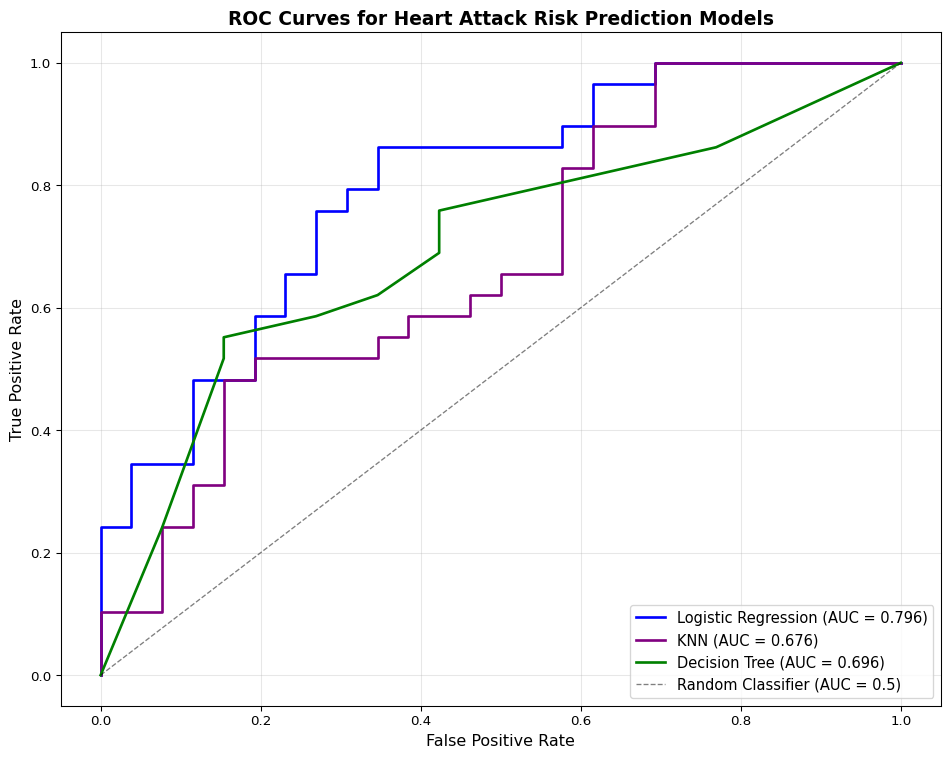

```python
plt.figure(figsize=(10, 8))
plt.plot(fpr_lr, tpr_lr, label=f'Logistic Regression (AUC = {auc_lr:.3f})',
         linewidth=2, color='blue')
plt.plot(fpr_knn, tpr_knn, label=f'KNN (AUC = {auc_knn:.3f})',
         linewidth=2, color='purple')
plt.plot(fpr_dt, tpr_dt, label=f'Decision Tree (AUC = {auc_dt:.3f})',
         linewidth=2, color='green')
plt.plot([0, 1], [0, 1], 'k--', label='Random Classifier (AUC = 0.5)',
         linewidth=1, alpha=0.5)

plt.xlabel('False Positive Rate', fontsize=12)
plt.ylabel('True Positive Rate', fontsize=12)
plt.title('ROC Curves for Heart Attack Risk Prediction Models', fontsize=14, fontweight='bold')
plt.legend(loc='lower right', fontsize=11)
plt.grid(alpha=0.3)
plt.tight_layout()
plt.show()
```

# PART TWO: CROSS-VALIDATED METRICS

```python
scoring = {
    'precision': make_scorer(precision_score),
    'recall': make_scorer(recall_score),
    'specificity': make_scorer(recall_score, pos_label=0)
}

knn_cv_scores = cross_validate(knn_grid.best_estimator_, X_train, y_train,
                                cv=cv, scoring=scoring)

knn_cv_scores['test_precision'].mean()
knn_cv_scores['test_recall'].mean()
knn_cv_scores['test_specificity'].mean()

lr_cv_scores = cross_validate(lr_grid.best_estimator_, X_train, y_train,
                               cv=cv, scoring=scoring)

lr_cv_scores['test_precision'].mean()
lr_cv_scores['test_recall'].mean()
lr_cv_scores['test_specificity'].mean()

dt_cv_scores = cross_validate(dt_grid.best_estimator_, X_train, y_train,
                               cv=cv, scoring=scoring)

dt_cv_scores['test_precision'].mean()
dt_cv_scores['test_recall'].mean()
dt_cv_scores['test_specificity'].mean()

metrics_comparison = pd.DataFrame({
    'Model': ['Logistic Regression', 'KNN', 'Decision Tree'],
    'CV Precision': [
        lr_cv_scores['test_precision'].mean(),
        knn_cv_scores['test_precision'].mean(),
        dt_cv_scores['test_precision'].mean()
    ],
    'CV Recall/Sensitivity': [
        lr_cv_scores['test_recall'].mean(),
        knn_cv_scores['test_recall'].mean(),
        dt_cv_scores['test_recall'].mean()
    ],
    'CV Specificity': [
        lr_cv_scores['test_specificity'].mean(),
        knn_cv_scores['test_specificity'].mean(),
        dt_cv_scores['test_specificity'].mean()
    ]
})

metrics_comparison
```

|  | Model | CV Precision | CV Recall/Sensitivity | CV Specificity |
| --- | --- | --- | --- | --- |
| 0 | Logistic Regression | 0.798893 | 0.819928 | 0.762381 |
| 1 | KNN | 0.787676 | 0.819928 | 0.742381 |
| 2 | Decision Tree | 0.786161 | 0.819565 | 0.732381 |

# PART THREE: DISCUSSION

Q1: Hospital faces severe lawsuits if they deem a patient low risk, and that patient later experiences a heart attack.

METRIC SELECTION: Recall/Sensitivity (True Positive Rate) We must minimize False Negatives

Q2: Hospital is overfull and wants to only use bed space for patients most in need of monitoring due to heart attack risk.

METRIC SELECTION: Precision Limited beds mean we can only admit patients truly at high risk We want to minimize False Positives

Q3: Hospital is studying root causes and wants to understand which biological measures are associated with heart attack risk.

METRIC SELECTION: Model Interpretability Need a model that provides clear, interpretable relationships

Q4: Hospital is training new doctors and wants to compare their diagnoses to the algorithm’s predictions.

METRIC SELECTION: Accuracy Accuracy will give us a good look at which doctors are doing the best

# PART FOUR: VALIDATION SET

```python
df_validation = pd.read_csv("https://www.dropbox.com/s/jkwqdiyx6o6oad0/heart_attack_validation.csv?dl=1")

X_val = df_validation.drop('output', axis=1)
y_val = df_validation['output']

y_pred_knn_val = knn_grid.predict(X_val)
y_proba_knn_val = knn_grid.predict_proba(X_val)[:, 1]
```

```python
print(confusion_matrix(y_val, y_pred_knn_val))
print(roc_auc_score(y_val, y_proba_knn_val))
print(precision_score(y_val, y_pred_knn_val))
print(recall_score(y_val, y_pred_knn_val))
```

```
[[10  1]
 [ 7 12]]
0.9234449760765551
0.9230769230769231
0.631578947368421
```

# Logistic Regression Validation

```python
y_pred_lr_val = lr_grid.predict(X_val)
y_proba_lr_val = lr_grid.predict_proba(X_val)[:, 1]
```

```python
print(confusion_matrix(y_val, y_pred_lr_val))
print(roc_auc_score(y_val, y_proba_lr_val))
print(precision_score(y_val, y_pred_lr_val))
print(recall_score(y_val, y_pred_lr_val))
```

```
[[10  1]
 [ 4 15]]
0.9234449760765551
0.9375
0.7894736842105263
```

# Decision Tree Validation

```python
y_pred_dt_val = dt_grid.predict(X_val)
y_proba_dt_val = dt_grid.predict_proba(X_val)[:, 1]
```

```python
print(confusion_matrix(y_val, y_pred_dt_val))
print(roc_auc_score(y_val, y_proba_dt_val))
print(precision_score(y_val, y_pred_dt_val))
print(recall_score(y_val, y_pred_dt_val))
```

```
[[11  0]
 [ 7 12]]
0.8612440191387559
1.0
0.631578947368421
```

# Comparison

```python
validation_comparison = pd.DataFrame({
    'Model': ['Logistic Regression', 'KNN', 'Decision Tree'],
    'Val ROC AUC': [
        roc_auc_score(y_val, y_proba_lr_val),
        roc_auc_score(y_val, y_proba_knn_val),
        roc_auc_score(y_val, y_proba_dt_val)
    ],
    'CV ROC AUC': [lr_grid.best_score_, knn_grid.best_score_, dt_grid.best_score_],
    'Val Precision': [
        precision_score(y_val, y_pred_lr_val),
        precision_score(y_val, y_pred_knn_val),
        precision_score(y_val, y_pred_dt_val)
    ],
    'CV Precision': [
        lr_cv_scores['test_precision'].mean(),
        knn_cv_scores['test_precision'].mean(),
        dt_cv_scores['test_precision'].mean()
    ],
    'Val Recall': [
        recall_score(y_val, y_pred_lr_val),
        recall_score(y_val, y_pred_knn_val),
        recall_score(y_val, y_pred_dt_val)
    ],
    'CV Recall': [
        lr_cv_scores['test_recall'].mean(),
        knn_cv_scores['test_recall'].mean(),
        dt_cv_scores['test_recall'].mean()
    ]
})

print(validation_comparison.to_string(index=False))
```

```
              Model  Val ROC AUC  CV ROC AUC  Val Precision  CV Precision  Val Recall  CV Recall
Logistic Regression     0.923445    0.861423       0.937500      0.798893    0.789474   0.819928
                KNN     0.923445    0.862697       0.923077      0.787676    0.631579   0.819928
      Decision Tree     0.861244    0.859643       1.000000      0.786161    0.631579   0.819565
```

The cross-validated estimates were approximately correct for the validation data. Minor differences are expected due to: - Small validation set size (30 observations) - Natural sampling variation - The validation set is truly independent (not used in any training/tuning)

Overall, the CV metrics provide reliable estimates of future performance.

# PART FIVE: COHEN’S KAPPA

```python
kappa_knn_test = cohen_kappa_score(y_test, y_pred_knn)
kappa_lr_test = cohen_kappa_score(y_test, y_pred_lr)
kappa_dt_test = cohen_kappa_score(y_test, y_pred_dt)

kappa_scorer = make_scorer(cohen_kappa_score)

kappa_knn_cv = cross_val_score(knn_grid.best_estimator_, X_train, y_train,
                                cv=cv, scoring=kappa_scorer)
kappa_lr_cv = cross_val_score(lr_grid.best_estimator_, X_train, y_train,
                               cv=cv, scoring=kappa_scorer)
kappa_dt_cv = cross_val_score(dt_grid.best_estimator_, X_train, y_train,
                               cv=cv, scoring=kappa_scorer)

kappa_knn_val = cohen_kappa_score(y_val, y_pred_knn_val)
kappa_lr_val = cohen_kappa_score(y_val, y_pred_lr_val)
kappa_dt_val = cohen_kappa_score(y_val, y_pred_dt_val)
```

```python
kappa_comparison = pd.DataFrame({
    'Model': ['Logistic Regression', 'KNN', 'Decision Tree'],
    'Test Kappa': [kappa_lr_test, kappa_knn_test, kappa_dt_test],
    'CV Kappa': [kappa_lr_cv.mean(), kappa_knn_cv.mean(), kappa_dt_cv.mean()],
    'Val Kappa': [kappa_lr_val, kappa_knn_val, kappa_dt_val],
    'CV Accuracy': [
        lr_cv_scores['test_recall'].mean(),
        knn_cv_scores['test_recall'].mean(),
        dt_cv_scores['test_recall'].mean()
    ]
})

print(kappa_comparison.to_string(index=False))
```

```
              Model  Test Kappa  CV Kappa  Val Kappa  CV Accuracy
Logistic Regression    0.451827  0.583633   0.660633     0.819928
                KNN    0.166117  0.564053   0.484979     0.819928
      Decision Tree    0.313854  0.553928   0.556962     0.819565
```

Cohen’s Kappa measures agreement between predictions and actual values while accounting for agreement that could happen by random chance. It’s especially useful when classes are imbalanced because regular accuracy can be misleading.

Kappa would be most useful in scenario Q4 because it directly measures how well the doctors’ diagnoses agree with the algorithm.